# Starwars Basic Dataset Analisys

By: Ricardo De León

Date: 29 de January de 2024

# Introduction

The “starwars” dataset is a built-in dataset available in the R package dplyr. This dataset contains information about various characters from the Star Wars universe. Below is a brief description of the variables included in this dataset:

- **name**: Name of the character.
- **height**: Height of the character in centimeters.
- **mass**: Mass of the character in kilograms.
- **hair_color**: Hair color of the character.
- **skin_color**: Skin color of the character.
- **eye_color**: Eye color of the character.
- **birth_year**: Birth year of the character (in the Star Wars universe).
- **sex**: Sex of the character.
- **gender**: Gender of the character.
- **homeworld**: Homeworld of the character.
- **species**: Species of the character.
- **films**: Movie participation
- **vehicules**: type of vehicle that is able to ride
- **starships**: type of star ships that is able to ride

My question in this dataset is analyze de characters by its **height** and **sex** to define if height and gender is a condition to act in the movie.

# Analysis

Load dataset and show a few columns.

```r
data("starwars")
head(starwars)
```

```
## # A tibble: 6 × 14
##   name      height  mass hair_color skin_color eye_color birth_year sex   gender
##   <chr>      <int> <dbl> <chr>      <chr>      <chr>          <dbl> <chr> <chr>
## 1 Luke Sky…    172    77 blond      fair       blue            19   male  mascu…
## 2 C-3PO        167    75 <NA>       gold       yellow         112   none  mascu…
## 3 R2-D2         96    32 <NA>       white, bl… red             33   none  mascu…
## 4 Darth Va…    202   136 none       white      yellow          41.9 male  mascu…
## 5 Leia Org…    150    49 brown      light      brown           19   fema… femin…
## 6 Owen Lars    178   120 brown, gr… light      blue            52   male  mascu…
## # ℹ 5 more variables: homeworld <chr>, species <chr>, films <list>,
## #   vehicles <list>, starships <list>
```

## Defining The New Dataset

Based on the condition we could create a filtered dataset with the few conditions (columns) and create a new dataset **starwars_df**

```r
starwars_df <- as.data.frame(dplyr::starwars) %>%
  dplyr::select(name,
                height,
                sex,
                films
                )
head(starwars_df)
```

```
##             name height    sex
## 1 Luke Skywalker    172   male
## 2          C-3PO    167   none
## 3          R2-D2     96   none
## 4    Darth Vader    202   male
## 5    Leia Organa    150 female
## 6      Owen Lars    178   male
##                                                                                                                                       films
## 1                                           A New Hope, The Empire Strikes Back, Return of the Jedi, Revenge of the Sith, The Force Awakens
## 2                    A New Hope, The Empire Strikes Back, Return of the Jedi, The Phantom Menace, Attack of the Clones, Revenge of the Sith
## 3 A New Hope, The Empire Strikes Back, Return of the Jedi, The Phantom Menace, Attack of the Clones, Revenge of the Sith, The Force Awakens
## 4                                                              A New Hope, The Empire Strikes Back, Return of the Jedi, Revenge of the Sith
## 5                                           A New Hope, The Empire Strikes Back, Return of the Jedi, Revenge of the Sith, The Force Awakens
## 6                                                                                     A New Hope, Attack of the Clones, Revenge of the Sith
```

## Null Values

```r
colSums(is.na(starwars_df))
```

```
##   name height    sex  films
##      0      6      4      0
```

For our new dataset we see that there are some missing values “na” but for this task we are not going to take care about the “na” so we are going to leave it present and be aware of those in the future.

## Graphics

We can analyze the distribution of heights in the following **Bar** graph

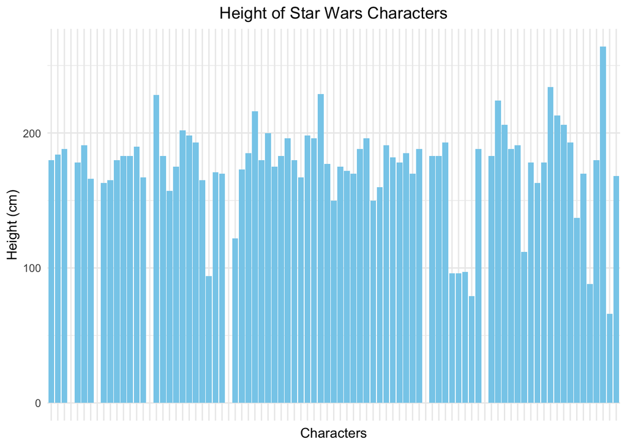

```r
ggplot(data = starwars_df, aes(x = name, y = height)) +
  geom_bar(stat = "identity", fill = "skyblue") +
  labs(x = "Characters",
       y = "Height (cm)") +
  theme_minimal() +
  theme(axis.text.x = element_blank(),
        plot.title = element_text(hjust = .5)) +
    ggtitle("Height of Star Wars Characters")
```

The following **Box Plot** shows better the heights out of range, or more deviated from the mean, this graph shows a better idea of max and min heights.

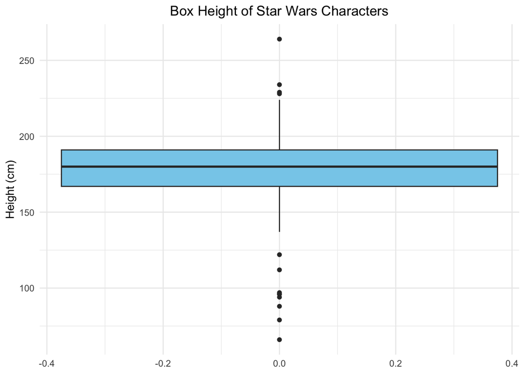

```r
ggplot(data = starwars_df, aes(y = height)) +
  geom_boxplot(fill = "skyblue") +
  labs(y = "Height (cm)") +
  theme_minimal() +
    theme(plot.title = element_text(hjust = .5)) +
  ggtitle("Box Height of Star Wars Characters")
```

The following lines of code show the **numeric analysis** reflecting what the graphs interpreted:

```r
min_height <- min(starwars_df$height, na.rm = TRUE)
max_height <- max(starwars_df$height, na.rm = TRUE)
mean_height <- mean(starwars_df$height, na.rm = TRUE)
sd_height <- sd(starwars_df$height, na.rm = TRUE)

cat("Height Summary Statistics:\n",
    "Minimum Height: ", min_height, "cm\n",
    "Maximum Height: ", max_height, "cm\n",
    "Mean Height: ", mean_height, "cm\n",
    "Standard Deviation (Variation) of Height: ", sd_height, "cm\n"
)
```

```
## Height Summary Statistics:
##  Minimum Height:  66 cm
##  Maximum Height:  264 cm
##  Mean Height:  174.6049 cm
##  Standard Deviation (Variation) of Height:  34.77416 cm
```

```r
# Calculate statistics grouped by sex
height_stats <- starwars_df %>%
  group_by(sex) %>%
  summarise(
    min_height = min(height, na.rm = TRUE),
    max_height = max(height, na.rm = TRUE),
    mean_height = mean(height, na.rm = TRUE),
    sd_height = sd(height, na.rm = TRUE)
  )

# Display the statistics as a table
kable(height_stats, caption = "Height Statistics Grouped by Sex", align = "c")
```

Height Statistics Grouped by Sex

| sex | min_height | max_height | mean_height | sd_height |
| --- | --- | --- | --- | --- |
| female | 150 | 213 | 171.5714 | 15.91185 |
| hermaphroditic | 175 | 175 | 175.0000 | NA |
| male | 66 | 264 | 179.1228 | 36.00946 |
| none | 96 | 200 | 131.2000 | 49.14977 |
| NA | 157 | 185 | 175.0000 | 12.35584 |

The following graphic shows the distribution of the highs according the sex of each character

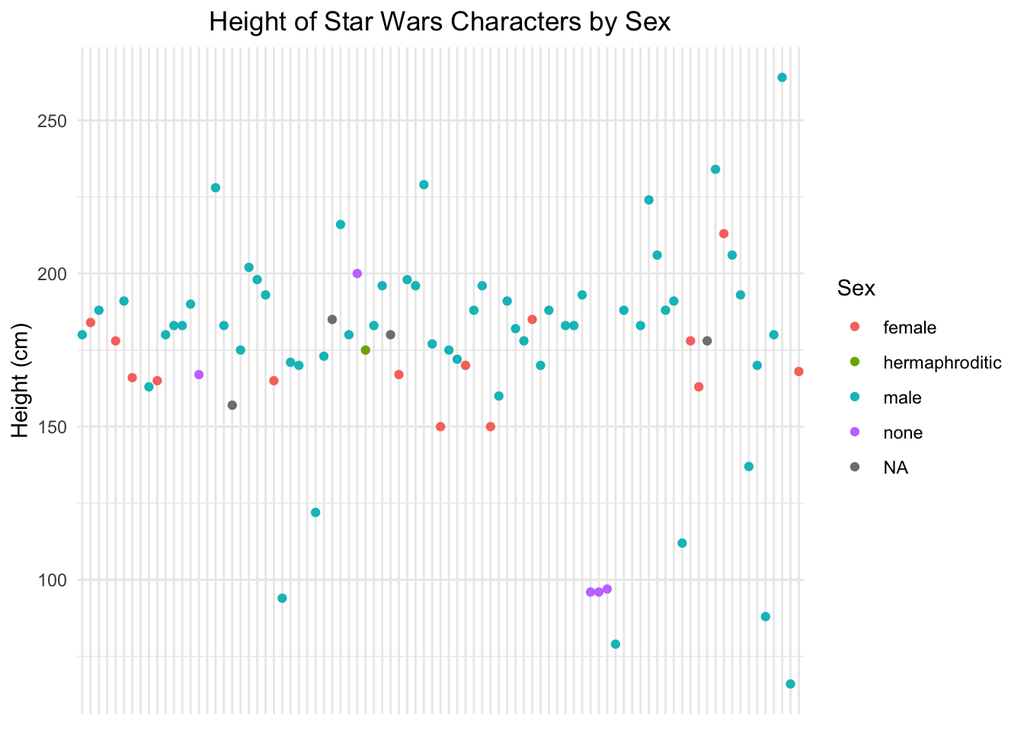

```r
ggplot(data = starwars_df, aes(x = name, y = height, color = sex)) +
  geom_point() +
  labs(x = NULL,
       y = "Height (cm)",
       color = "Sex") +
    theme_minimal() +
    theme(axis.text.x = element_blank(),
          plot.title = element_text(hjust = 0.5)) +
  ggtitle("Height of Star Wars Characters by Sex")
```

# Conclusions

We can see in the plot that mean of the height is between 150 and 200 cm. We could think that more male characters are in this height however most of the characters are male, so it is normal that more male fit on this height.